# Segurança Alimentar, Certificação e Indicações Geográficas · Da Produção ao Consumo Responsável

Extensão Rural

Prof. Dr. Luiz Diego Vidal Santos

## Abertura Visão Geral da Aula

Roteiro da aula Tópicos estruturantes

- 1 Segurança Alimentar e Nutricional (SAN)
- 2 Soberania Alimentar
- 3 Certificação Orgânica no Brasil
- 4 Sistemas Participativos de Garantia (SPG)
- 5 Indicações Geográficas (IG)
- 6 O Papel do Extensionista na SAN

Objetivo central Da produção ao consumo responsável

Compreender os conceitos de segurança e soberania alimentar, os mecanismos de certificação de produtos orgânicos e as indicações geográficas como estratégias de valorização da agricultura familiar e de promoção do desenvolvimento rural sustentável.

LOSAN · SISAN Auditoria · SPG · OCS IP · DO · INPI

Conectando direito humano à alimentação, certificação participativa e mercados territoriais.

# Segurança e Soberania Alimentar

## SAN Segurança Alimentar e Nutricional (SAN)

**LOSAN (Lei 11.346/2006, Art. 3°):** *“realização do direito de todos ao acesso regular e permanente a alimentos de qualidade, em quantidade suficiente, sem comprometer o acesso a outras necessidades essenciais, tendo como base práticas alimentares promotoras de saúde que respeitem a diversidade cultural e que sejam ambiental, cultural, econômica e socialmente sustentáveis.”*

01 · Disponibilidade Produção e oferta

Sistemas produtivos diversificados, sustentáveis e abastecimento local.

02 · Acesso Renda e distribuição

Capacidade econômica e canais regulares de obtenção de alimentos.

03 · Utilização biológica Qualidade e higiene

Valor nutricional, processamento, conservação e inocuidade sanitária.

04 · Estabilidade Regularidade temporal

Continuidade do acesso frente a secas, crises e choques de preços.

A extensão rural incide diretamente sobre a **disponibilidade** (diversificação produtiva) e a **utilização biológica** (processamento, conservação e higiene alimentar — Maluf, 2007).

## SAN Insegurança Alimentar e o Paradoxo Brasileiro

POF (IBGE, 2020) · VIGISAN (2022) O paradoxo alimentar brasileiro

O país figura entre os maiores produtores e exportadores mundiais de alimentos, mas não assegura acesso alimentar adequado a parcela expressiva da população.

Vulnerabilidade no campo Quem mais sofre no meio rural

Agricultores familiares do semiárido, comunidades quilombolas, povos indígenas e assentados da reforma agrária concentram índices críticos de insegurança alimentar (IBGE, 2020).

**33,1 milhões** de brasileiros viviam em **insegurança alimentar grave (fome)** segundo o VIGISAN (2022).

**125,2 milhões** enfrentavam algum grau de insegurança alimentar no país.

**Desigualdade regional:** maior incidência concentrada nas regiões Norte e Nordeste.

**Recorte interseccional:** domicílios chefiados por mulheres negras são os mais atingidos.

**Assimetria rural-urbana:** o meio rural apresenta proporcionalmente maior insegurança alimentar que o urbano.

## Soberania Soberania Alimentar e Controle dos Sistemas

**Via Campesina (1996):** *“o direito dos povos de definir suas próprias políticas e estratégias sustentáveis de produção, distribuição e consumo de alimentos, garantindo o direito à alimentação para toda a população, com base na pequena e média produção, respeitando suas próprias culturas e a diversidade dos modos camponeses de produção e comercialização.”*

Foco no “O Quê” Segurança Alimentar (SAN)

Garante acesso regular e permanente a alimentos suficientes, seguros e de qualidade nutricional para toda a população.

Foco no “Como” e “Por Quem” Soberania Alimentar

Questiona quem controla os sistemas alimentares, defendendo circuitos curtos, sementes crioulas, mercados locais e agroecologia (Maluf, 2007).

Para o extensionista, articular SAN e soberania alimentar significa fortalecer a autonomia produtiva e alimentar das famílias rurais.

## Políticas Políticas Públicas de SAN no Brasil

| Política / Programa | Ano | Contribuição para a SAN |
| --- | --- | --- |
| **LOSAN (Lei 11.346)** | 2006 | Define SAN como direito humano e cria o SISAN |
| **PAA** | 2003 | Compra direta da agricultura familiar para doação e estoques |
| **PNAE (Lei 11.947)** | 2009 | Mínimo de **30%** da alimentação escolar oriunda da agricultura familiar |
| **Programa Cisternas** | 2003 | Acesso à água para consumo e produção no semiárido |
| **PNAPO (Decreto 7.794)** | 2012 | Fomento à agroecologia e à produção orgânica |
| **Programa Brasil Sem Fome** | 2023 | Retomada articulada de ações de combate à fome |

A **extensão rural** é componente transversal dessas políticas, atuando da diversificação produtiva à habilitação para compras públicas (Grisa e Schneider, 2015).

# Certificação Orgânica e SPG

## Certificação Conformidade Orgânica e Compras Públicas

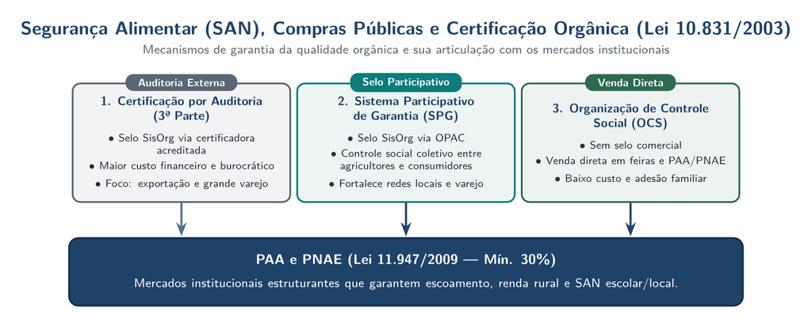

Fluxo dos três mecanismos de avaliação da conformidade orgânica conectados ao PAA e PNAE.

Avaliação da Conformidade Orgânica (Lei 10.831/2003) e Articulação com PAA/PNAE Auditoria de 3ª Parte, Sistema Participativo de Garantia (SPG) e Organização de Controle Social (OCS) · Lei 11.947/2009 (Mín. 30%)

## Certificação Mecanismos de Avaliação da Conformidade Orgânica

01 · Auditoria (3ª parte) Certificadoras credenciadas

- Emissão do selo SisOrg por certificadora credenciada pelo MAPA
- Custo financeiro e burocrático mais elevado
- Voltada a exportação, grande varejo e escalas maiores

02 · SPG Sistema Participativo de Garantia

- Emite selo SisOrg via **OPAC** credenciado ao MAPA
- Controle social coletivo entre agricultores, consumidores e técnicos
- Acessível à agricultura familiar e coerente com a agroecologia

03 · OCS Organização de Controle Social

- Venda **direta** ao consumidor final sem selo comercial
- Exige cadastro ativo no MAPA e rastreabilidade do grupo
- Baixo custo para feiras locais e vendas institucionais (PAA/PNAE)

**Lei 10.831/2003 e Decreto 6.323/2007:** cada mecanismo atende a públicos e escalas distintas, democratizando o acesso da agricultura familiar à garantia orgânica.

## Certificação Sistemas Participativos de Garantia (SPG) na Prática

Decreto 6.323/2007 · OPAC Confiança e controle compartilhado

Credenciados pelo MAPA como **Organismos Participativos de Avaliação da Conformidade (OPACs)**, os SPGs unem rigor normativo, participação social e emissão do selo orgânico nacional.

Referência nacional · Meirelles (2010) Rede Ecovida de Agroecologia

Maior experiência brasileira de SPG, articulando mais de **4.500 famílias agricultoras** em **27 núcleos regionais** nos três estados do Sul do Brasil.

**1.** Grupo de agricultores constitui um núcleo territorial

**2.** Visitas periódicas de verificação cruzada entre pares

**3.** Participação ativa de consumidores e técnicos no controle

**4.** Registro formal do grupo no MAPA como OPAC

**5.** Emissão do selo orgânico brasileiro para mercados formais

**6.** Custo expressivamente menor que a auditoria de terceira parte

# Indicações Geográficas (IG)

## Território Indicações Geográficas: IP e DO (Lei 9.279/1996)

Modalidade 1 · Reputação Indicação de Procedência (IP)

Reconhece região que se tornou conhecida como centro de extração, produção ou fabricação de determinado produto ou serviço.

- **Foco:** reputação histórica do território
- **Exemplos:** Vale dos Vinhedos (RS — vinhos) e Litoral Norte Gaúcho (arroz)

Modalidade 2 · Terroir Denominação de Origem (DO)

Reconhece produto cujas qualidades ou características se devem **exclusivamente** ao meio geográfico, incluindo fatores naturais e humanos.

- **Foco:** vínculo qualidade-território comprovado cientificamente
- **Exemplos:** Região do Cerrado Mineiro (café) e Costa Negra (CE — camarão)

**Registro no INPI:** o Instituto Nacional da Propriedade Industrial é o órgão responsável. Até **2024**, o Brasil contabilizava **mais de 100 IGs registradas**, com forte expansão no setor agropecuário.

## Território IGs e Agricultura Familiar: Potencial e Riscos

01 · Papel do Extensionista Construção coletiva

Realizar diagnósticos locais, apoiar a organização coletiva, articular instituições de pesquisa na caracterização do produto e facilitar o registro no INPI (Niederle, 2013).

02 · Casos Familiares Identidade territorial

- Própolis Vermelha de Alagoas
- Queijo Artesanal do Serro (MG)
- Cachaça da Região de Salinas (MG)
- Aguardente de Paraty (RJ)

03 · Desafios e Cuidados Risco de exclusão

Exige conformidade com cadernos de especificação técnica, infraestrutura e marketing territorial; há risco recorrente de exclusão de pequenos produtores na área delimitada (Niederle, 2013).

A IG agrega valor a saberes tradicionais apenas quando governada de forma inclusiva pelas organizações da agricultura familiar.

# Atuação do Extensionista e Circuitos Curtos

## Atuação O Extensionista na Promoção da SAN

**1. Diversificação produtiva:** ampliação de cultivos alimentares para autoconsumo e venda.

**2. Processamento local:** agregação de valor, higiene e conservação de alimentos.

**3. Acesso a mercados:** habilitação e logística para **PAA** e **PNAE**.

**4. Certificação (SPG/OCS):** construção de confiança e conformidade orgânica acessível.

**5. Organização comunitária:** gestão coletiva da produção, beneficiamento e comercialização.

Visão sistêmica · Maluf (2007) Além da tecnologia produtiva

Todos os cinco eixos de trabalho do extensionista convergem para a promoção da **Segurança Alimentar e Nutricional** no campo e na cidade, superando a assistência técnica puramente produtivista.

Produzir com diversidade + beneficiar no território + certificar coletivamente + escoar em mercados justos = **SAN sustentável**.

## Diagrama Campos de Atuação do(a) Extensionista na SAN

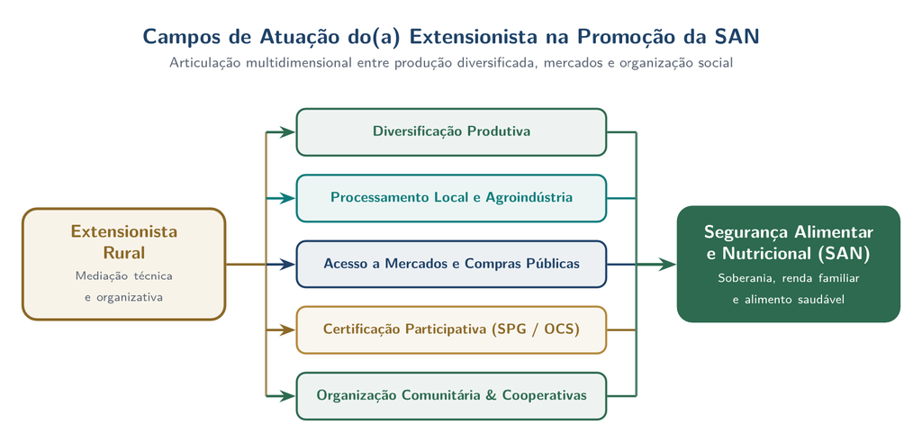

Atuação Sistêmica do Extensionista na Promoção da Segurança Alimentar e Nutricional Convergência entre diversificação produtiva, processamento local, mercados institucionais, SPG/OCS e organização comunitária

A promoção da **SAN** demanda atuação integrada do extensionista do campo à mesa, articulando produção agroecológica e mercados de proximidade.

## Mercados Sistemas Alimentares Locais e Circuitos Curtos

Schneider et al. (2020) Circuitos curtos de comercialização

Aproximam produtores e consumidores, reduzem cadeias intermediárias e promovem simultaneamente **SAN** (alimentos frescos), **soberania alimentar** e **viabilidade econômica** familiar.

Modalidades em expansão no Brasil Canais diretos e institucionais

1. Feiras agroecológicas e familiares (**+7.000** no país)
2. Entregas em domicílio (cestas orgânicas)
3. Grupos de Consumo Responsável (GCR) e cooperativas
4. Compras públicas (**PAA**, **PNAE**) e plataformas digitais

[figure not shown]

II Feira Baiana da Agricultura Familiar e Economia Solidária em Salvador, Bahia.

II Feira Baiana da Agricultura Familiar e Economia Solidária Salvador/BA · Foto: Neusa Cadore (CC-BY 2.0) · Encontro direto entre campo e cidade

## Síntese Conclusão

Articulação estratégica SAN, Certificação e Origem

Integrar SAN, soberania alimentar, certificação orgânica (SPG/OCS) e Indicações Geográficas capacita o extensionista a apoiar sistemas diversificados e mercados que valorizam qualidade, origem e atributos socioambientais.

Superação do paradoxo Direito humano e território

A extensão rural comprometida com a SAN conecta o potencial produtivo agrário brasileiro ao **direito humano à alimentação adequada** e ao fortalecimento dos sistemas alimentares territoriais.

Da produção diversificada à mesa do consumidor: certificação e mercados territoriais garantem autonomia à agricultura familiar.

## Referências Referências da Aula

Bloco 1 · Legislação e Marcos Normativos Leis e decretos estruturantes

- Brasil. *Lei 9.279/1996*. Propriedade Industrial (1996).
- Brasil. *Lei 10.831/2003*. Agricultura Orgânica (2003).
- Brasil. *Lei 11.346/2006*. Lei Orgânica de Segurança Alimentar (LOSAN).
- Brasil. *Lei 11.947/2009*. Programa Nacional de Alimentação Escolar (PNAE).
- Brasil. *Decreto 6.323/2007*. Regulamentação da agricultura orgânica.
- Brasil. *Decreto 7.794/2012*. Política Nacional de Agroecologia e Produção Orgânica (PNAPO).

Bloco 2 · Literatura e Inquéritos Estudos de SAN, SPG, IG e mercados

- Grisa, C.; Schneider, S. Três gerações de políticas públicas para a agricultura familiar. *Revista de Economia e Sociologia Rural*, v. 52, p. 125–146, 2015.
- IBGE. *Pesquisa de Orçamentos Familiares 2017–2018* (2020).
- Maluf, R. S. *Segurança Alimentar e Nutricional*. Petrópolis: Vozes, 2007.
- Meirelles, L. *Certificação participativa: a experiência da Rede Ecovida*. Ipê: Centro Ecológico, 2010.
- Niederle, P. A. *Indicações geográficas: qualidade e origem nos mercados alimentares*. Porto Alegre: UFRGS, 2013.
- Rede PENSSAN. *VIGISAN: Inquérito Nacional sobre Insegurança Alimentar* (2022).
- Schneider, S. et al. *A pandemia e os sistemas alimentares no Brasil*. Porto Alegre: UFRGS, 2020.
- Via Campesina. *Declaração sobre Soberania Alimentar*. Roma, 1996.

Obrigado!

Luiz Diego Vidal Santos

Universidade Estadual de Feira de Santana (UEFS)